# Weekly Cafe Sales

Tyrae

2026-10-17

**AI Assistance Declaration:** I used ChatGPT to help draft this documentation and assist with the R script. Prompts included “Help me to write a Cafe Sales R script”. I ran the script in Posit Cloud and inspected its console output and chart. Knitting this report and independently checking the calculations are done by student.

# Purpose

This project shows a week of made-up cafe cup sales. The script displays the daily sales, calculates the total and daily average, and creates a bar chart.

The goal is to make the script easy to understand and show how R Markdown combines explanations, code, and results.

The data is written directly inside `weekly_sales.R`. No external dataset is needed.

| Day | Cups sold |
| --- | --- |
| Monday | 120 |
| Tuesday | 135 |
| Wednesday | 150 |
| Thursday | 140 |
| Friday | 210 |
| Saturday | 280 |
| Sunday | 240 |

These numbers are fictional. They do not come from a real cafe or contain personal information.

# Requirements

The script uses the `ggplot2` package to create the chart. Rendering this report also requires `rmarkdown` and `knitr`.

Keep `weekly_sales.R` and `weekly_sales.Rmd` in the same folder.

# How the Script Works

## Store the Data

The script creates a data frame called `sales_data`. Its columns contain the day names and the number of cups sold.

The days are stored as a factor with a specific order. This keeps the chart in Monday-to-Sunday order.

## Display the Table

The script uses `print()` to display the sales data in the Console. This makes it easy to check the values used in the chart.

## Calculate the Summary

The script uses `sum()` to calculate the weekly total and `mean()` to calculate the daily average. The displayed average is rounded to one decimal place.

These calculations were checked independently in Sheets.

## Create the Chart

The script uses `ggplot()` and `geom_col()` to create brown bars for the daily sales. Labels above the bars show the supplied cup counts.

The chart includes a title and axis labels so the reader knows what the values represent. The script uses `print(sales_plot)` to display the chart when it is sourced.

# Run the Script and Show Results

The chunk below runs the saved script. Its printed results and chart should appear in the knitted report.

```r
source("weekly_sales.R", local = knitr::knit_global())
```

```
## === Weekly Cafe Cup Sales (Made-up Data) ===
##        Day Cups_Sold
##     Monday       120
##    Tuesday       135
##  Wednesday       150
##   Thursday       140
##     Friday       210
##   Saturday       280
##     Sunday       240
##
## Total Cups Sold: 1275
## Daily Average: 182.1
```

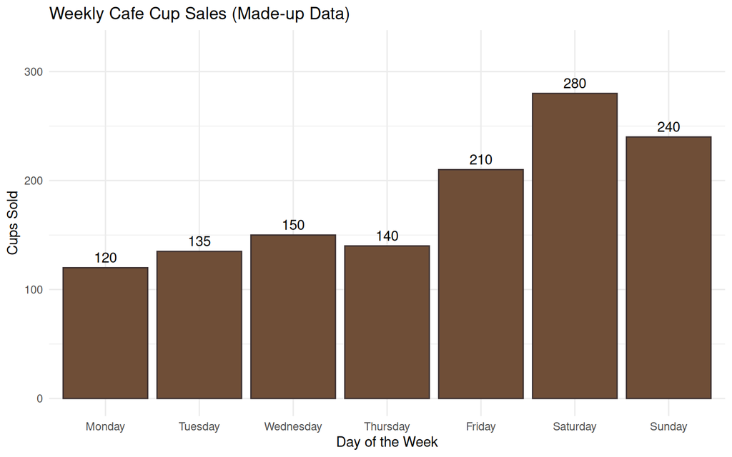

# Outputs

The script produces:

- A table showing the daily cup sales.
- A weekly sales total.
- A daily average rounded to one decimal place.
- A labeled bar chart comparing the days.

Knitting this document produces `weekly_sales.html`. The script does not save a separate chart image.

# Verification

The script was run in Posit Cloud. The Console displayed the sales data and summary, and the Plots pane displayed the brown bar chart.

# Limitations

The data is made up, so the results cannot explain actual customer behaviour or support real business decisions. This project only demonstrates a simple R workflow and its documentation.